# Pre-processing with phyloseq

Ezra Seckin

2026-04-22

```r
knitr::opts_knit$set(root.dir = "/workdir/eas456/CRCBacterialConsortia_AmpliconProject")  # ← set to your actual project root
knitr::opts_chunk$set(echo = TRUE,
                      fig.align = "center",
                      # send any figure output to this folder
                      fig.path = "../../figures/03_PreProcessing/")
```

# Goals

The goal with this file is to pre-process any other contaminants and unexpected ASVs from our sample. We will need to:

1. Remove any contaminating ASVs that are **chloroplasts**.
2. Remove ASVs that are **mitochondria**.
3. Evaluate any ASVs from the **negative controls**. Then, remove negative controls.
4. Evaluate the mock community or **positive control** to learn the accuracy of sequencing.
5. Check for **reverse complements**.
6. Check the **sequencing depth** of samples. Remove samples that obviously have too few reads.
7. Add the metadata for class dataset (Note: Your data may already be in your `sample_data()`).
8. Write a `preprocessed_physeq` to be used in the next step of our workflow.

## Input

Here, we will start with the phyloseq object that we created in 02_AssignASVs.Rmd

1. **Raw phyloseq object**: We will need `data/02_AssignASVs/raw_phyloseq.RData`.
2. **Mock Amplicon Fasta**: Please copy over the `mock_amplicons.fasta` from `/workdir/in_class_data/` to your `data/03_PreProcessing` folder.

## Output

1. We will write out a complex R data object known as an **S4** object, which in this case is known as a phyloseq output. We will store this in `data/03_PreProcessing/preprocessed_phyloseq.RData`.

# Set up the Environment

## Set the seeds and threads

```r
# Set the seed for reproducibility
set.seed(238428)
```

## Timing of this script

Let’s record how long this file took to run on the class server, which we will record at the end of the script.

```r
# What time did we start running this script?
start_time <- Sys.time()
```

## Load packages

```r
# Load packages
pacman::p_load(devtools, phyloseq, Biostrings, tidyverse, dada2, patchwork,
               # Note to add ggpubr & rstatix!!
               ggpubr, rstatix, install = FALSE)
```

# Load Phyloseq Data

```r
# Load the data
load("data/02_AssignASVs/raw_physeq.RData")

# Look at the data
raw_physeq
```

```
## phyloseq-class experiment-level object
## otu_table()   OTU Table:         [ 7401 taxa and 41 samples ]
## sample_data() Sample Data:       [ 41 samples by 38 sample variables ]
## tax_table()   Taxonomy Table:    [ 7401 taxa by 9 taxonomic ranks ]
```

# Clean up the data

**Chloroplasts** and **mitochondria** need to be removed from 16S datasets because they contain their own 16S rRNA genes, which are evolutionarily derived from bacteria. These organelles can be unintentionally amplified during PCR, especially in samples from plants (chloroplasts) or animals (mitochondria), leading to misleading results by inflating microbial diversity.

This is explained by the endosymbiotic theory, which proposes that mitochondria and chloroplasts originated from free-living bacteria that were engulfed by ancestral eukaryotic cells. Over time, they became permanent, symbiotic organelles with their own genomes. Because of this bacterial ancestry, their 16S rRNA genes are similar to those targeted in bacterial 16S profiling, even though they are part of the host organism and not part of the microbial community being studied.

Removing these sequences ensures the analysis reflects true bacterial and archaeal diversity in the environment or host.

## 1. Remove Chloroplasts

```r
# Let's tak a quick look at the tax table
# View(tax_df) # Let's see where chloroplasts are and also mitochondria

# Make new physeq without chloroplasts
noChloros_physeq <-
  raw_physeq %>%
  # rm chloroplasts, which are Order
  subset_taxa(Order != "Chloroplast" | is.na(Order))

# How many taxa were chloroplasts?
num_chloro_ASVs <- ntaxa(raw_physeq) - ntaxa(noChloros_physeq)
num_chloro_ASVs
```

```
## [1] 9
```

```r
# Intuition chek
#noChloros_physeq %>%
#  tax_table() %>%
#  data.frame() %>%
#  View()
```

There were 9 ASVs that were chloroplasts.

## 2. Remove Mitochondria

```r
# remove mitochondria
noChlorosMitos_physeq <-
  noChloros_physeq %>%
  subset_taxa(Family != "Mitochondria" | is.na(Family))

# How many mitochondrial ASVs?
num_mito_ASVs <- ntaxa(noChloros_physeq) - ntaxa(noChlorosMitos_physeq)
num_mito_ASVs
```

```
## [1] 3
```

```r
# Let's take a quick look
noChlorosMitos_physeq
```

```
## phyloseq-class experiment-level object
## otu_table()   OTU Table:         [ 7389 taxa and 41 samples ]
## sample_data() Sample Data:       [ 41 samples by 38 sample variables ]
## tax_table()   Taxonomy Table:    [ 7389 taxa by 9 taxonomic ranks ]
```

There were 3 ASVs that were mitochondria in the data set.

INTERPRETATION #1: How many chloroplast and/or mitochondrial ASVs in your dataset? Does this seem reasonable?

```r
# How many total asvs were removed from chloros and mitos?
ntaxa(raw_physeq) - ntaxa(noChlorosMitos_physeq)
```

```
## [1] 12
```

```r
# proportion of asvs kept?
ntaxa(noChlorosMitos_physeq)/ntaxa(raw_physeq)
```

```
## [1] 0.9983786
```

# Evaulate and remove the control samples

Now, let’s take a look at the negative controls and then make a decision about whether or not to remove the ASVs that we found in our controls

1. Negative controls
2. ASVs found within the negative controls and their distribution in the samples.
3. Evaluate the mock community

## 3. Negative Controls

Including negative controls in your 16S sequencing workflow is a critical step that helps you identify potential contamination and confidently interpret your results—**especially if you’re working with low-biomass** samples like water, air, or host-associated (*e.g.,* skin, etc) surfaces.

Even in the cleanest labs, contamination can creep in at any point in the pipeline: from the DNA extraction kit, PCR reagents, plastic consumables, or even aerosols in the lab. These contaminants often include low-level bacterial DNA that can be amplified just as efficiently as your true sample DNA, leading to false signals in your data. Negative controls help you detect and remove these artifacts.

The main types of negative controls you should consider including in your 16S rRNA gene analyses include the following:

1. **DNA Extraction Blank (Extraction Negative Control):** This control is processed alongside your samples but without any actual biological material—you just use the extraction buffer or nuclease-free water. It goes through the entire DNA extraction process, just like your real samples. Each time you open a new kit another DNA extraction blank should be created! In our lab, we always record the lot number of our extraction kit and add it to the DNA metadata for that sample.
   - *Why it’s important:* This control helps you detect contamination introduced during the extraction step—often from kits (a phenomenon known as the kitome), tubes, pipette tips, or other surfaces.
2. **PCR No-Template Control (NTC):** For this control, you set up a PCR reaction using water instead of DNA as the template. Everything else—primers, polymerase, buffer—is the same as your actual PCR reactions.
   - *Why it’s important:* This checks for contaminants introduced during PCR setup, such as aerosolized DNA, primer dimer artifacts, or contamination from reagents like Taq or water.
   - *Note:* A NTC control should be included in your dataset from each step of PCR that your sample goes through. For example, **in the standard Illumina 2-step PCR library prep, two separate NTC controls should be included** for both the 1st PCR step where the 16S rRNA gene-specific primers are used with the Illumina adapter overhangs, and the 2nd PCR step where the indices and P5 and P7 are added to the end of the amplicons. Therefore, a blank sample that is carried all the way through barcoding, library prep, pooling, and sequencing. Treat it exactly like a real sample in your workflow. These control helps detect contamination introduced within and after PCR, such as cross-contamination during amplicon pooling, barcode cross-talk, or reagent contamination during library preparation.
3. **Field Control:** This type of control is a blank sample (*e.g.,* sterile water, buffer, or a clean swab) that is handled *exactly* like your real samples, but without exposure to the environment or biological material that is being studied. It goes through:
   - The same collection materials (e.g., bottles, filters, swabs).
   - The same handling (e.g., gloves, tools, transport containers).
   - And is stored or processed at the same time and under the same conditions as your actual field samples.
   - Extracted and prepared exactly as every other sample.
   - *What are examples of field controls?*
     - Examples:
       - *Water samples:* Pour sterile water into a sterile sampling bottle at the site (without exposing it to the lake/river), filter it as if it were a sample.
       - *Swab samples:* Open a sterile swab, wave it near the sampling area without touching anything, then store it with your other samples.
       - *Sediment or soil samples*: Open up the collection tube to the open air and use a clean scoop (with the same cleaning method as you would between actual samples) to transfer sterile material or nothing at all into your collection container.

Negative controls are not optional—they are essential for data quality, reproducibility, and trust in your results. By including extraction blanks, PCR no-template controls, and field controls, you’ll be equipped to identify contamination, assess its impact, and clean your data before making biological interpretations.

**So, here in this section we will use the negative control samples to:**

1. Make a phyloseq object that only has our negative controls.
2. Evaluate negative control ASVs in samples versus controls by visualizing potential ASV contaminants in negative controls using plots. Here, we will manually do it, but please be aware that there’s also the [decontam R Package](https://benjjneb.github.io/decontam/vignettes/decontam_intro.html) that does this, too!
3. Remove any ASVs in the negative controls.

*Our dataset does not include negative controls to analyze, so we will skip over this code chunk*

INTERPRETATION #2: Did your dataset have any negative controls? If so, how many ASVs did you remove? Does that seem reasonable to you?

*Our dataset doesn’t include positive controls either, so we will skip over this code chunk, too*

# 5. Reverse Complements

## Why are reverse complements in my dataset?

During PCR amplification, sequencing, or bioinformatics processing, it’s possible that some sequences get read in the reverse orientation, are assigned to the wrong strand, or are present as both the forward and reverse complement versions in your dataset. This is especially common when using non-strand-specific sequencing protocols, the pipeline doesn’t enforce consistent orientation, or working with merged paired-end reads and haven’t filtered by orientation yet.

If you don’t check for reverse complements, you may accidentally treat identical sequences (just read in opposite directions) as different ASVs or OTUs. This can:

- Inflate your diversity estimates (counts two taxa when reality there is just one).
- Split read counts, reducing the apparent abundance of that ASV,
- Complicate taxonomic assignments, since tools may give different results depending on strand orientation.

## How to identify reverse complements?

- You can search your ASV or OTU table for reverse complement matches.
- If two sequences are reverse complements of each other, you can merge them and recalculate abundances.
- Tools like VSEARCH, USEARCH, or even custom scripts in R or Python can help identify reverse complements.
- Some pipelines (like DADA2) handle this automatically if you process all reads with the same orientation. This can be done in the `filterAndTrim()` step by using the `orient.fwd` parameter. But if you merge reads from multiple sources, it’s worth checking.

Reverse complements can show up in your dataset when identical sequences are read or processed in opposite orientations. If not accounted for, they can artificially inflate diversity and confuse your analyses. By searching for and collapsing reverse complements, you ensure that your 16S data is more accurate and biologically meaningful.

So, here we will manually search for reverse complements in the dataset since we forgot to use the `orient.fwd` parameter in our `filterAndTrim()` step. And, it’s always good to double check, even if we did!

```r
# Pull out Taxa Table
# NOTE: Using noChlorosMitos_physeq since this dataset has no negative controls
# or mock community to remove, so we skip directly from chloro/mito removal
tax_table <-
  noChlorosMitos_physeq %>%
  tax_table() %>%
  data.frame()

# Grab ASV Sequences and Names
asv_names <- tax_table$ASV
asv_seqs <- tax_table$ASVseqs

# Create empty comparison matrix
asv_rev_comp <- matrix(nrow = length(asv_seqs), ncol = length(asv_seqs))

# Fix the names in the rows and columns
rownames(asv_rev_comp) <- asv_names
colnames(asv_rev_comp) <- asv_names

# Convert sequences to Biostrings
asv_dna <- DNAStringSet(asv_seqs)

# Inspect
head(asv_dna)
```

```
## DNAStringSet object of length 6:
##     width seq
## [1]   427 TGGGGAATATTGCACAATGGGCGCAAGCCTGATG...GACGCTCAGGTGCGAAAGCGTGGGGAGCAAACA
## [2]   408 TCGAGAATCATTCACAATGGGGGAAACCCTGATG...GACGCTGAGGCACGAAGGCCAGGGGAGCGAAAG
## [3]   422 TGAGGAATATTGGTCAATGGGCGAGAGCCTGAAC...GACATTGAGGCTCGAAAGTGTGGGTATCAAACA
## [4]   422 TGAGGAATATTGGTCAATGGACGCAAGTCTGAAC...GACGTTGAGGCACGAAAGCGTGGGGAGCAAACA
## [5]   405 TGGGGAATATTGGACAATGGACCAAAAGTCTGAT...GACGCTAAAGCGCGAAAGCGTGGGTAGCAAACA
## [6]   422 TGAGGAATATTGGTCAATGGACGAGAGTCTGAAC...GACGCTGATGCTCGAAAGTGTGGGTATCAAACA
```

```r
# Construct reverse complement
asv_rev_dna <- reverseComplement(asv_dna)

# Now loop through every asv sequence to check
for(i in 1:length(asv_seqs)){
  match_vec <- asv_dna[i] == asv_rev_dna
  asv_rev_comp[, i] <- match_vec
}

# Find how many TRUEs (matches), divide by 2 because each pair occurs twice
cat("For", sum(asv_rev_comp) / 2, "ASVs, the reverse complement will need to be removed")
```

```
## For 0 ASVs, the reverse complement will need to be removed
```

INTERPRETATION #4: Do you have any reverse complements in your dataset?

# 6. Sequencing Depth

Sequencing depth (also known as the library size of a sample) is the number of reads per sample. It affects how well we can detect and compare microbes between samples. Normalizing for sequencing depth is essential for fair and accurate analysis in microbial studies.

At first glance, you might expect that different types of samples—like soil, water, or gut—would naturally have different sequencing depths. After all, they have different microbial loads, right? But in practice, sequencing depth is more about the lab and sequencing process than the biology of the sample itself.

Remember that:

- **Sequencing depth reflects how many reads are returned—not microbial biomass**
  - Sequencing depth is the number of reads assigned to a sample after sequencing—not the number of microbes present.
  - Two samples (*e.g.,* one from soil, one from water) can end up with the same number of reads, even if one has far more microbial biomass than the other.
  - This is because library preparation, PCR efficiency, and pooling determine how many reads each sample gets—not the sample’s biology.
- **Sequencing depth is ifluenced by gechnical factors**
  - *DNA extraction efficiency*: Some samples (*e.g.,* soil) are harder to extract DNA from, but if extraction is successful, the sequencing depth can still be high.
  - *PCR amplification*: Some samples amplify better than others due to inhibitors or DNA quality, but PCR bias can equalize or distort actual abundance.
  - *Pooling strategy*: When libraries are pooled before sequencing, each sample is assigned a roughly equal proportion of reads, regardless of the sample type.
  - *Demultiplexing* errors or sequencing bias can also affect how many reads are recovered per sample.
- **Sequencing depth is not a measure of microbial diversity or complexity**
  - A complex community (*e.g.,* soil) and a simple one (*e.g.,* a mock community) can both be sequenced to the same depth.
  - You may need higher sequencing depth to capture rare taxa in complex communities, but the sequencer won’t automatically give you that—it just sequences what’s there in the library.

## Why does sequencing depth matter?

- Higher depth = better detection of rare microbes.
- Too low depth may miss important community members and give unreliable diversity estimates.
- Uneven depth across samples can bias comparisons between microbial communities.

## How to deal with unequal sequencing depth?

We often normalize for sequencing depth before comparing samples using methods like:

- *Rarefaction*: Subsampling many times (typically 1,000 times) to an even depth.
- *Scaling*: Transform sample counts by multiplying by the ASV count by the minimum library size in the dataset.
- *Proportional normalization*: Converting to relative abundance (all ASV values within a sample add up to 1).
- *Statistical modeling*: DESeq2, which accounts for depth.

Let’s take a look!

```r
# The current data object
noChlorosMitos_physeq
```

```
## phyloseq-class experiment-level object
## otu_table()   OTU Table:         [ 7389 taxa and 41 samples ]
## sample_data() Sample Data:       [ 41 samples by 38 sample variables ]
## tax_table()   Taxonomy Table:    [ 7389 taxa by 9 taxonomic ranks ]
```

```r
# Make a metadata_df for joining
metadata_df <-
  noChlorosMitos_physeq %>%
  sample_data() %>%
  data.frame() %>%
  rownames_to_column(var = "names")

# What is the library size/sequencing depth for each sample?
seqSums_df <-
  noChlorosMitos_physeq %>%
  otu_table() %>%
  colSums() %>%
  data.frame() %>%
  rownames_to_column(var = "names") %>%
  left_join(., metadata_df, by = "names")

# Rename second column
colnames(seqSums_df)[2] <- "TotalSeqs"

# Check
dim(seqSums_df)
```

```
## [1] 41 40
```

```r
head(seqSums_df)
```

```
##        names TotalSeqs        Run Assay.Type AvgSpotLen     Bases  BioProject
## 1 SRR3666998    192245 SRR3666998   AMPLICON        501 128745713 PRJNA325650
## 2 SRR3666999    148226 SRR3666999   AMPLICON        511  82928818 PRJNA325650
## 3 SRR3667000    196943 SRR3667000   AMPLICON        511 113298648 PRJNA325650
## 4 SRR3667001    139429 SRR3667001   AMPLICON        511  82229757 PRJNA325650
## 5 SRR3667002    105951 SRR3667002   AMPLICON        504  62451815 PRJNA325650
## 6 SRR3667003     96989 SRR3667003   AMPLICON        505  63146651 PRJNA325650
##      BioSample                             BioSampleModel    Bytes
## 1 SAMN05248685 MIMARKS.survey,MIGS/MIMS/MIMARKS.human-gut 67022027
## 2 SAMN05248658 MIMARKS.survey,MIGS/MIMS/MIMARKS.human-gut 40962824
## 3 SAMN05248698 MIMARKS.survey,MIGS/MIMS/MIMARKS.human-gut 58158352
## 4 SAMN05248671 MIMARKS.survey,MIGS/MIMS/MIMARKS.human-gut 40686686
## 5 SAMN05248699 MIMARKS.survey,MIGS/MIMS/MIMARKS.human-gut 31754967
## 6 SAMN05248672 MIMARKS.survey,MIGS/MIMS/MIMARKS.human-gut 31848224
##            Center.Name chem_administration Collection_Date Consent
```

[output cut: 48 more lines]

```r
# Show the depth of samples
seqSums_df %>%
  dplyr::select(names, TotalSeqs) %>%
  arrange(TotalSeqs) %>%
  head()
```

```
##        names TotalSeqs
## 1 SRR3667027     68274
## 2 SRR3667039     74057
## 3 SRR3667033     77179
## 4 SRR3667028     78566
## 5 SRR3667035     82259
## 6 SRR3667005     85864
```

```r
# Plot it as a bar plot — colored by a metadata column in YOUR dataset
# First check what columns are available:
colnames(seqSums_df)  # ← run this first to confirm the right column name to use below
```

```
##  [1] "names"                          "TotalSeqs"
##  [3] "Run"                            "Assay.Type"
##  [5] "AvgSpotLen"                     "Bases"
##  [7] "BioProject"                     "BioSample"
##  [9] "BioSampleModel"                 "Bytes"
## [11] "Center.Name"                    "chem_administration"
## [13] "Collection_Date"                "Consent"
## [15] "DATASTORE.filetype"             "DATASTORE.provider"
## [17] "DATASTORE.region"               "env_biome"
## [19] "env_feature"                    "env_material"
## [21] "ethnicity"                      "Experiment"
## [23] "geo_loc_name_country"           "geo_loc_name_country_continent"
## [25] "geo_loc_name"                   "Host"
## [27] "host_tissue_sampled"            "Instrument"
## [29] "lat_lon"                        "Library.Name"
## [31] "LibraryLayout"                  "LibrarySelection"
## [33] "LibrarySource"                  "Organism"
## [35] "Platform"                       "ReleaseDate"
## [37] "Sample.Name"                    "SRA.Study"
## [39] "create_date"                    "version"
```

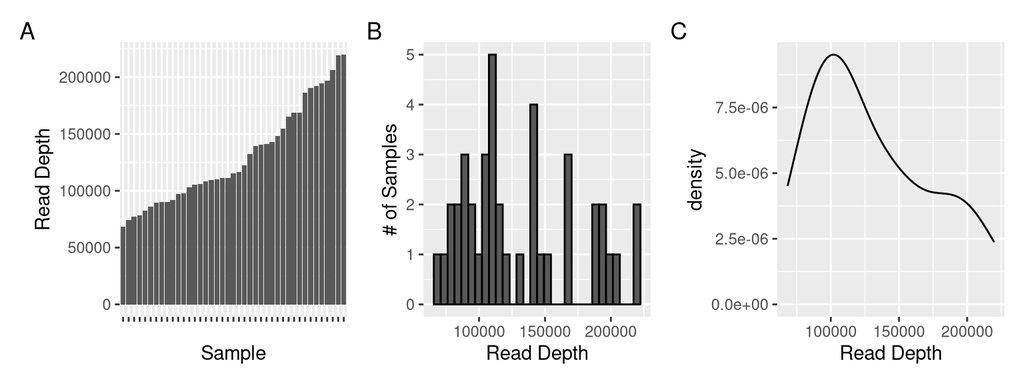

```r
numSeq_bar_plot <-
  seqSums_df %>%
  ggplot(aes(x = reorder(names, TotalSeqs), y = TotalSeqs)) +
  geom_bar(stat = "identity") +
  theme(axis.text.x = element_blank()) +
  labs(y = "Read Depth", x = "Sample")

# Histogram
numSeq_hist_plot <-
  seqSums_df %>%
  ggplot(aes(x = TotalSeqs)) +
  geom_histogram(color = "black") +
  labs(y = "# of Samples", x = "Read Depth")

# Density plot
numSeq_density_plot <-
  seqSums_df %>%
  ggplot(aes(TotalSeqs)) +
  geom_density(alpha = 0.5) +
  labs(x = "Read Depth")

# Put it all together
numSeq_bar_plot + numSeq_hist_plot + numSeq_density_plot +
  plot_annotation(tag_levels = "A")
```

INTERPRETATION #5: What can you conclude about your sequencing depths? What are your sample distributions? Do you have “enough” reads? Are there any samples that should be removed at this step?

## Remove samples with few reads

If you find any samples that should obviously be removed at this step, you can follow the code below for your samples. However, if your samples have some but not many reads—like 1000 counts-it is worthwhile to keep those samples in your dataset and remove them later, especially if they are very important!

You can watch this video by [Dr. Pat Schloss](https://riffomonas.org/code_club/2022-04-07-sampling-depth), which talks about how to find the best sampling depth for rarefaction to give you some idea.

```r
# What's the min seq depth?
min(sample_sums(noChlorosMitos_physeq))
```

```
## [1] 68274
```

```r
# Show full sequencing depth table to identify any samples to remove
seqSums_df %>%
  dplyr::select(names, TotalSeqs) %>%
  arrange(TotalSeqs)
```

```
##         names TotalSeqs
## 1  SRR3667027     68274
## 2  SRR3667039     74057
## 3  SRR3667033     77179
## 4  SRR3667028     78566
## 5  SRR3667035     82259
## 6  SRR3667005     85864
## 7  SRR3667043     89415
## 8  SRR3667034     90026
## 9  SRR3667020     90191
## 10 SRR3667018     92098
## 11 SRR3667003     96989
## 12 SRR3667026     97536
## 13 SRR3667040    102789
## 14 SRR3667037    105097
```

[output cut: 27 more lines]

```r
# Remove any samples with obviously too few reads
# ← Update the sample name below based on the arrange() output above
# If no samples need to be removed, just assign directly:
preprocessed_physeq <- noChlorosMitos_physeq

# If you DO need to remove a sample, comment out the line above and use this instead:
# preprocessed_physeq <-
#   noChlorosMitos_physeq %>%
#   subset_samples(., names != "YOUR_LOW_DEPTH_SAMPLE_HERE")

# What's the new min seq depth?
min(sample_sums(preprocessed_physeq))
```

```
## [1] 68274
```

```r
# Final intuition check
preprocessed_physeq
```

```
## phyloseq-class experiment-level object
## otu_table()   OTU Table:         [ 7389 taxa and 41 samples ]
## sample_data() Sample Data:       [ 41 samples by 38 sample variables ]
## tax_table()   Taxonomy Table:    [ 7389 taxa by 9 taxonomic ranks ]
```

# 7. Add Sequencing Depth to Metadata

Since your metadata is already loaded from the SRA Run Table, you do not need to create new categorical variables like `salinity_group` as those were specific to the in-class dataset. However, we will add the sequencing depth to your existing metadata so that information is not lost in downstream analyses.

```r
# Pull current metadata from the preprocessed phyloseq object
metadata_df <-
  preprocessed_physeq %>%
  sample_data() %>%
  data.frame() %>%
  rownames_to_column(var = "names")

# Add sequencing depth to the metadata
num_seqs_df <-
  preprocessed_physeq %>%
  sample_sums() %>%
  data.frame() %>%
  rownames_to_column(var = "names")

# Fix the column name
colnames(num_seqs_df)[2] <- "Sequencing_Depth"

# Merge sequencing depth into metadata
metadata_df2 <-
  metadata_df %>%
  left_join(num_seqs_df, by = "names")

# Confirm rows match before reassigning
stopifnot(metadata_df$names == metadata_df2$names)

# Rename the rows to match sample names
rownames(metadata_df2) <- metadata_df2$names

# Reassign updated metadata back to the phyloseq object
sample_data(preprocessed_physeq) <- metadata_df2

# Confirm the new column is there
colnames(data.frame(sample_data(preprocessed_physeq)))
```

```
##  [1] "names"                          "Run"
##  [3] "Assay.Type"                     "AvgSpotLen"
##  [5] "Bases"                          "BioProject"
##  [7] "BioSample"                      "BioSampleModel"
##  [9] "Bytes"                          "Center.Name"
## [11] "chem_administration"            "Collection_Date"
## [13] "Consent"                        "DATASTORE.filetype"
## [15] "DATASTORE.provider"             "DATASTORE.region"
## [17] "env_biome"                      "env_feature"
## [19] "env_material"                   "ethnicity"
## [21] "Experiment"                     "geo_loc_name_country"
## [23] "geo_loc_name_country_continent" "geo_loc_name"
## [25] "Host"                           "host_tissue_sampled"
## [27] "Instrument"                     "lat_lon"
## [29] "Library.Name"                   "LibraryLayout"
## [31] "LibrarySelection"               "LibrarySource"
## [33] "Organism"                       "Platform"
## [35] "ReleaseDate"                    "Sample.Name"
## [37] "SRA.Study"                      "create_date"
## [39] "version"                        "Sequencing_Depth"
```

```r
# Intuition check
head(num_seqs_df)
```

```
##        names Sequencing_Depth
## 1 SRR3666998           192245
## 2 SRR3666999           148226
## 3 SRR3667000           196943
## 4 SRR3667001           139429
## 5 SRR3667002           105951
## 6 SRR3667003            96989
```

# 8. Write out the data

Finally, let’s save our phyloseq object, which we will use for the next step!

```r
# Save the preprocessed phyloseq object
save(preprocessed_physeq,
     file = "data/03_PreProcessing/preprocessed_phyloseq.RData")
```

# Final info for Reproducibility

## Check Render Time

```r
# Take the time now that we are at the end of the script
end_time <- Sys.time()
end_time
```

```
## [1] "2026-04-22 16:04:07 EDT"
```

```r
# Echo the elapsed time
elapsed_time <- round((end_time - start_time), 3)
elapsed_time
```

```
## Time difference of 24.597 secs
```